# BayesianFinal

```python
! pip install pymc
```

```python
import os
import glob
import pickle
import numpy as np
import pandas as pd
import librosa
import torch
import pymc as pm
import pytensor.tensor as pt
import arviz as az
import matplotlib.pyplot as plt
from sklearn.metrics import accuracy_score
from transformers import Wav2Vec2Processor, Wav2Vec2Model
```

```python
from transformers import pipeline
from huggingface_hub import login

# Authenticate with your token
login("logintoken")

# Load the private model
pipe = pipeline("automatic-speech-recognition", model="kehanlu/mandarin-wav2vec2-aishell1", token=True)
```

```
Some weights of Wav2Vec2ForCTC were not initialized from the model checkpoint at kehanlu/mandarin-wav2vec2-aishell1 and are newly initialized: ['lm_head.bias', 'lm_head.weight']
You should probably TRAIN this model on a down-stream task to be able to use it for predictions and inference.
Hardware accelerator e.g. GPU is available in the environment, but no `device` argument is passed to the `Pipeline` object. Model will be on CPU.
```

```python
# Initialize the pre-trained Mandarin Wav2Vec2 model and processor
processor = Wav2Vec2Processor.from_pretrained("kehanlu/mandarin-wav2vec2")
model = Wav2Vec2Model.from_pretrained("kehanlu/mandarin-wav2vec2")
model.eval()
```

[output not shown]

```python
def load_audio(file_path, target_sr=16000):
    audio, sr = librosa.load(file_path, sr=None, mono=True)
    if sr != target_sr:
        audio = librosa.resample(audio, orig_sr=sr, target_sr=target_sr)
    audio, _ = librosa.effects.trim(audio)
    return audio, target_sr

def extract_audio_embedding(audio, sr):
    input_values = processor(audio, sampling_rate=sr, return_tensors="pt").input_values
    with torch.no_grad():
        outputs = model(input_values)
    # Average over time dimension to get a fixed-length embedding
    mean_embedding = outputs.last_hidden_state.mean(dim=1).squeeze().numpy()
    return mean_embedding

def load_subject_all_embeddings(subject_dir):
    """
    For a given subject folder, load each of the 29 recordings separately
    and extract its embedding.
    Returns a dictionary mapping recording number (str) to embedding.
    """
    embeddings = {}
    for file in glob.glob(os.path.join(subject_dir, "*.wav")):
        # Extract recording number from file name (e.g., "1.wav" becomes "1")
        recording_number = os.path.splitext(os.path.basename(file))[0]
        try:
            audio, sr = load_audio(file, target_sr=16000)
            emb = extract_audio_embedding(audio, sr)
            embeddings[recording_number] = emb
        except Exception as e:
            print(f"Error processing {file}: {e}")
    return embeddings

def load_all_subject_embeddings(base_audio_dir, subject_id_ignore=["02010004"], output_file="subject_embeddings.pkl"):
    """
    Loads embeddings for all subjects (ignoring certain subject ids with contaminated daat).
    Returns a dictionary mapping participant_id (as str) to a dictionary of 29 task embeddings.
    """

    if os.path.exists(output_file):
        # Load embeddings
        print(f"Loading embeddings from {output_file}")
        with open(output_file, "rb") as f:
            subject_embeddings = pickle.load(f)
        print(f"Loaded embeddings for {len(subject_embeddings)} subjects")
    else:
        print("No existing embeddings found. Extracting and saving new embeddings...")
        subject_embeddings = {}
        for subject_folder in os.listdir(base_audio_dir):
            if subject_folder.isdigit() and subject_folder not in subject_id_ignore:
                print(f"Processing {subject_folder}")
                # Ignore non-subject folders
                subject_path = os.path.join(base_audio_dir, subject_folder)
                # Load each of the 29 recordings separately and extract its embedding
                emb_dict = load_subject_all_embeddings(subject_path)
                subject_embeddings[subject_folder] = emb_dict
                print(f"Processed {len(emb_dict)} recordings for {subject_folder}")
        # Save embeddings
        print(f"Saving embeddings to {output_file}")
        with open(output_file, "wb") as f:
            pickle.dump(subject_embeddings, f)
        print(f"Saved embeddings for {len(subject_embeddings)} subjects")

    return subject_embeddings
```

```python
# Set the base directory where each participant's audio files are stored
base_audio_dir = "/Users/ireneliu/Desktop/BAY/Final_Project/Data/audio_lanzhou_2015"
```

```python
subject_embeddings = load_all_subject_embeddings(base_audio_dir)
```

```
Loading embeddings from subject_embeddings.pkl
Loaded embeddings for 51 subjects
```

```python
# Load labels for each subject
subjects_information_path = "/Users/ireneliu/Desktop/BAY/Final_Project/Data/audio_lanzhou_2015/subjects_information_audio_lanzhou_2015.xlsx"
labels_df = pd.read_excel(subjects_information_path, dtype={"subject_id": str})
labels_df

# Filter and order labels to match the subject_ids (folder names)
subject_ids = list(subject_embeddings.keys())
labels_df = labels_df.set_index('subject_id').loc[subject_ids].reset_index()

# Define the target variable
y = labels_df['type'].values

print("Target variable: ", y)
```

```
Target variable:  ['MDD' 'HC' 'HC' 'HC' 'MDD' 'MDD' 'MDD' 'HC' 'HC' 'HC' 'MDD' 'HC' 'HC'
 'HC' 'HC' 'MDD' 'HC' 'HC' 'MDD' 'HC' 'HC' 'HC' 'HC' 'HC' 'HC' 'HC' 'MDD'
 'MDD' 'HC' 'HC' 'MDD' 'MDD' 'HC' 'MDD' 'MDD' 'MDD' 'MDD' 'HC' 'MDD' 'HC'
 'MDD' 'MDD' 'HC' 'HC' 'HC' 'MDD' 'MDD' 'MDD' 'HC' 'MDD' 'HC']
```

```python
# Convert y from strings to numeric labels: MDD -> 1, HC -> 0
label_map = {'MDD': 1, 'HC': 0}
y = np.array([label_map[label] for label in y])
print(y)
```

```
[1 0 0 0 1 1 1 0 0 0 1 0 0 0 0 1 0 0 1 0 0 0 0 0 0 0 1 1 0 0 1 1 0 1 1 1 1
 0 1 0 1 1 0 0 0 1 1 1 0 1 0]
```

```python
# Define the subgroups based on the experiment:
# Interview recordings:
#   Positive: recordings 1-6
#   Neutral: recordings 7-12
#   Negative: recordings 13-18
# Short story: recording 19
# Reading:
#   Positive: recordings 20-21
#   Neutral: recordings 22-23
#   Negative: recordings 24-25
# Picture description: recordings 26-28
# TAT: recording 29

subgroups = {
    'interview_positive': ['01', '02', '03', '04', '05', '06'],
    'interview_neutral': ['07', '08', '09', '10', '11', '12'],
    'interview_negative': ["13", "14", "15", "16", "17", "18"],
    'short_story': ["19"],
    'reading_positive': ["20", "21"],
    'reading_neutral': ["22", "23"],
    'reading_negative': ["24", "25"],
    'picture_description': ["26", "27", "28"],
    'tat': ["29"]
}
```

```python
def fuse_subgroup_embeddings(emb_dict, recording_indices):
    """
    Fuse embeddings for subgroups of recordings using average pooling.

    Parameters:
        emb_dict (dict): Mapping from recording number (str) to embedding.
        recording_indices (list): List of recording numbers (int) to fuse.

    Returns:
        fused (np.ndarray): The fused embedding vector.
    """
    embeddings = []
    for idx in recording_indices:
        key = str(idx)
        if key in emb_dict:
            embeddings.append(emb_dict[key])
        else:
            print(f"Recording {key} not found!")
    embeddings = np.vstack(embeddings)

    # Average pooling
    return embeddings.mean(axis=0)
```

```python
fused_data = {}
for subject_id, emb_dict in subject_embeddings.items():
    print(f"Processing {subject_id}")
    subgroup_fused = {}
    for subgroup_name, indices in subgroups.items():
        fused_embedding = fuse_subgroup_embeddings(emb_dict, indices)
        if fused_embedding is not None:
            subgroup_fused[subgroup_name] = fused_embedding
    if subgroup_fused:
        fused_data[subject_id] = subgroup_fused
print(f"Processed {len(fused_data)} subjects")
```

[output not shown]

```python
# Define a fixed order for your subgroups:
subgroup_order = [
    'interview_positive', 'interview_neutral', 'interview_negative',
    'short_story', 'reading_positive', 'reading_neutral', 'reading_negative',
    'picture_description', 'tat'
]

# Build the 3D array: one row per subject, each with shape (n_subgroups, feature_dim)
X_sub = []  # List to collect each subject's subgroup embeddings

for subject_id, subgroup_dict in fused_data.items():
    # Ensure that we have all subgroups; if a subgroup is missing, we skip it or fill with zeros.
    subject_embedding = []
    for subgroup in subgroup_order:
        if subgroup in subgroup_dict:
            subject_embedding.append(subgroup_dict[subgroup])
        else:
            # Option: Fill with zeros if a subgroup is missing
            d = list(subgroup_dict.values())[0].shape[0] if subgroup_dict else 768  # default dimension
            subject_embedding.append(np.zeros(d))
    subject_embedding = np.vstack(subject_embedding)  # shape: (n_subgroups, feature_dim)
    X_sub.append(subject_embedding)

# Convert to a NumPy array: shape (n_subjects, n_subgroups, feature_dim)
X = np.stack(X_sub, axis=0)
print(f"X_tensor shape: {X.shape}")
```

```
X_tensor shape: (51, 9, 768)
```

## Step 1: Bayesian Gaussian Process Classification (GPC)

# Gaussian Process Classification (GPC) is useful when working with small datasets and provides uncertainty quantification.

```python
from sklearn.gaussian_process import GaussianProcessClassifier
from sklearn.gaussian_process.kernels import RBF

# Flatten the embeddings for classification (reshape subjects into 2D)
X_flat = X.reshape(X.shape[0], -1)  # Shape (n_subjects, n_subgroups * feature_dim)

# Define kernel for Gaussian Process
kernel = 1.0 * RBF(length_scale=1.0)

# Train Gaussian Process Classifier
gpc = GaussianProcessClassifier(kernel=kernel, random_state=42)
gpc.fit(X_flat, y)

# Make predictions
y_pred_gpc = gpc.predict(X_flat)
accuracy_gpc = accuracy_score(y, y_pred_gpc)
print(f"Gaussian Process Classifier Accuracy: {accuracy_gpc:.4f}")
```

```
Gaussian Process Classifier Accuracy: 0.9412
```

Why Use GPC? ✅ Captures non-linear patterns ✅ Provides uncertainty estimation ✅ Works well for small datasets

## Step 2: Bayesian Logistic Regression

use PyMC to build a Bayesian logistic regression model.

```
Initializing NUTS using jitter+adapt_diag...
Multiprocess sampling (4 chains in 4 jobs)
NUTS: [w, b]
```

```
Output()
```

```
Sampling 4 chains for 1_000 tune and 1_000 draw iterations (4_000 + 4_000 draws total) took 2 seconds.
There were 4000 divergences after tuning. Increase `target_accept` or reparameterize.
The rhat statistic is larger than 1.01 for some parameters. This indicates problems during sampling. See https://arxiv.org/abs/1903.08008 for details
The effective sample size per chain is smaller than 100 for some parameters.  A higher number is needed for reliable rhat and ess computation. See https://arxiv.org/abs/1903.08008 for details
```

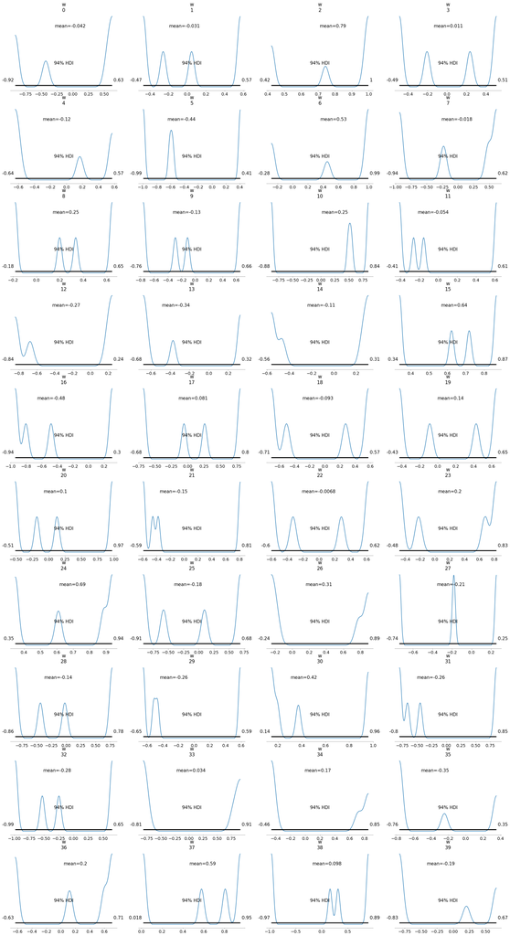

```python
import pymc as pm
import pytensor.tensor as pt

# Standardize X_flat for better Bayesian modeling
X_standardized = (X_flat - X_flat.mean(axis=0)) / X_flat.std(axis=0)

with pm.Model() as bayesian_logistic_model:
    # Priors for weights and intercept
    w = pm.Normal("w", mu=0, sigma=1, shape=(X_standardized.shape[1],))
    b = pm.Normal("b", mu=0, sigma=1)

    # Likelihood function (logistic regression)
    logits = pt.dot(X_standardized, w) + b
    y_obs = pm.Bernoulli("y_obs", logit_p=logits, observed=y)

    # Sample from the posterior
    trace = pm.sample(1000, return_inferencedata=True)

# Visualize results
az.plot_posterior(trace, var_names=["w", "b"])
plt.show()
```

```
Initializing NUTS using jitter+adapt_diag...
Multiprocess sampling (4 chains in 4 jobs)
NUTS: [mu_w, sigma_w, w, b]
```

```
Output()
```

```
Sampling 4 chains for 1_000 tune and 2_000 draw iterations (4_000 + 8_000 draws total) took 3 seconds.
There were 8000 divergences after tuning. Increase `target_accept` or reparameterize.
The effective sample size per chain is smaller than 100 for some parameters.  A higher number is needed for reliable rhat and ess computation. See https://arxiv.org/abs/1903.08008 for details
```

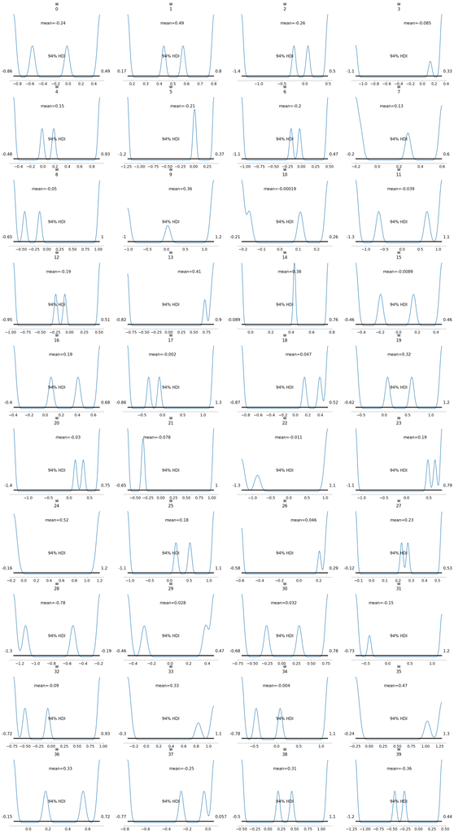

```python
import pymc as pm
import pytensor.tensor as pt
import arviz as az
import matplotlib.pyplot as plt
import numpy as np
from sklearn.metrics import accuracy_score, precision_score, recall_score, roc_auc_score

# Standardize input features for better stability
X_standardized = (X_flat - X_flat.mean(axis=0)) / X_flat.std(axis=0)

# Define Bayesian Logistic Regression Model
with pm.Model() as bayesian_logistic_model:
    # Hierarchical Priors: Assume weights have a Gaussian prior
    mu_w = pm.Normal("mu_w", mu=0, sigma=1)  # Mean prior for weights
    sigma_w = pm.HalfNormal("sigma_w", sigma=1)  # Scale prior for weights
    w = pm.Normal("w", mu=mu_w, sigma=sigma_w, shape=(X_standardized.shape[1],))

    # Prior for Intercept
    b = pm.Normal("b", mu=0, sigma=1)

    # Likelihood (Logistic Regression)
    logits = pt.dot(X_standardized, w) + b
    y_obs = pm.Bernoulli("y_obs", logit_p=logits, observed=y)

    # Sampling with the No-U-Turn Sampler (NUTS)
    trace = pm.sample(2000, tune=1000, return_inferencedata=True, target_accept=0.9)

# Visualize Posterior Distributions
az.plot_posterior(trace, var_names=["w", "b"])
plt.show()
```

```python
# Extract posterior samples for predictions
posterior_w = trace.posterior["w"].mean(dim=("chain", "draw")).values
posterior_b = trace.posterior["b"].mean(dim=("chain", "draw")).values

# Compute logits for test data
logits_test = np.dot(X_standardized, posterior_w) + posterior_b
y_pred_probs = 1 / (1 + np.exp(-logits_test))  # Convert logits to probabilities

# Convert to binary predictions using a threshold (default 0.5)
threshold = 0.5
y_pred = (y_pred_probs > threshold).astype(int)

# Evaluate performance
accuracy = accuracy_score(y, y_pred)
precision = precision_score(y, y_pred)
recall = recall_score(y, y_pred)
auc = roc_auc_score(y, y_pred_probs)

# Print Results
print(f"✅ Bayesian Logistic Regression Results:")
print(f"📊 Accuracy: {accuracy:.4f}")
print(f"🎯 Precision: {precision:.4f}")
print(f"🔄 Recall: {recall:.4f}")
print(f"📈 ROC-AUC: {auc:.4f}")
```

```
✅ Bayesian Logistic Regression Results:
📊 Accuracy: 0.4706
🎯 Precision: 0.4000
🔄 Recall: 0.4545
📈 ROC-AUC: 0.5517
```

🔹 1. Find the Best Classification Threshold Since 0.5 is not optimal, let's test different thresholds:

```python
import numpy as np
from sklearn.metrics import classification_report, roc_auc_score

# Test different thresholds to find the best recall-precision balance
thresholds = np.linspace(0.1, 0.9, 9)
for t in thresholds:
    y_pred_t = (y_pred_probs > t).astype(int)
    precision = precision_score(y, y_pred_t)
    recall = recall_score(y, y_pred_t)
    auc = roc_auc_score(y, y_pred_t)
    print(f"Threshold: {t:.2f} | Precision: {precision:.4f} | Recall: {recall:.4f} | AUC: {auc:.4f}")
```

```
Threshold: 0.10 | Precision: 0.4643 | Recall: 0.5909 | AUC: 0.5368
Threshold: 0.20 | Precision: 0.4231 | Recall: 0.5000 | AUC: 0.4914
Threshold: 0.30 | Precision: 0.4000 | Recall: 0.4545 | AUC: 0.4687
Threshold: 0.40 | Precision: 0.4000 | Recall: 0.4545 | AUC: 0.4687
Threshold: 0.50 | Precision: 0.4000 | Recall: 0.4545 | AUC: 0.4687
Threshold: 0.60 | Precision: 0.4167 | Recall: 0.4545 | AUC: 0.4859
Threshold: 0.70 | Precision: 0.4167 | Recall: 0.4545 | AUC: 0.4859
Threshold: 0.80 | Precision: 0.4167 | Recall: 0.4545 | AUC: 0.4859
Threshold: 0.90 | Precision: 0.4167 | Recall: 0.4545 | AUC: 0.4859
```

Recall is the priority!

Missing a depressed patient (False Negative) can be dangerous because they might not get the care they need. False Positives (healthy people labeled as depressed) are less harmful—they can be ruled out with further evaluation. 🔹 Conclusion: Use a lower threshold (0.10 - 0.30) to maximize recall. 🔹 However, we should still try to improve precision without sacrificing recall too much.

BNN and Logistic Regression may not fully capture uncertainty. Let's try Gaussian Processes:

```python
import gpytorch
import torch

# Convert to tensor
X_train_tensor = torch.tensor(X_standardized, dtype=torch.float32)
y_train_tensor = torch.tensor(y, dtype=torch.float32)

# Define Gaussian Process Model
class GPRegressionModel(gpytorch.models.ExactGP):
    def __init__(self, train_x, train_y, likelihood):
        super(GPRegressionModel, self).__init__(train_x, train_y, likelihood)
        self.mean_module = gpytorch.means.ConstantMean()
        self.covar_module = gpytorch.kernels.ScaleKernel(gpytorch.kernels.RBFKernel())

    def forward(self, x):
        mean_x = self.mean_module(x)
        covar_x = self.covar_module(x)
        return gpytorch.distributions.MultivariateNormal(mean_x, covar_x)

# Define model and likelihood
likelihood = gpytorch.likelihoods.GaussianLikelihood()
model = GPRegressionModel(X_train_tensor, y_train_tensor, likelihood)

# Training the model
model.train()
likelihood.train()
optimizer = torch.optim.Adam(model.parameters(), lr=0.1)
mll = gpytorch.mlls.ExactMarginalLogLikelihood(likelihood, model)

for i in range(100):
    optimizer.zero_grad()
    output = model(X_train_tensor)
    loss = -mll(output, y_train_tensor)
    loss.backward()
    optimizer.step()
    if i % 10 == 0:
        print(f"Iteration {i} - Loss: {loss.item():.3f}")
```

```
Iteration 0 - Loss: 1.238
Iteration 10 - Loss: 0.895
Iteration 20 - Loss: 0.719
Iteration 30 - Loss: 0.738
Iteration 40 - Loss: 0.718
Iteration 50 - Loss: 0.719
Iteration 60 - Loss: 0.716
Iteration 70 - Loss: 0.717
Iteration 80 - Loss: 0.716
Iteration 90 - Loss: 0.716
```

🚨 Key Observations 🔹 The GP model is learning and converging at loss ~0.716. 🔹 Some fluctuations (30-40 iterations), which could mean the model is adjusting its hyperparameters. 🔹 Unclear model performance metrics—we need AUC, Accuracy, Precision, and Recall to compare to Logistic Regression.

🚀 Next Step Test the model predictions on your dataset and compute classification metrics like AUC, Recall, and Accuracy:

```python
from sklearn.metrics import accuracy_score, precision_score, recall_score, roc_auc_score

# Convert GP outputs to predictions
y_pred_gp_probs = model(X_train_tensor).mean.detach().numpy()
y_pred_gp = (y_pred_gp_probs > 0.5).astype(int)

# Evaluate performance
print("Gaussian Process Classification Results:")
print("📊 Accuracy:", accuracy_score(y, y_pred_gp))
print("🎯 Precision:", precision_score(y, y_pred_gp))
print("🔄 Recall:", recall_score(y, y_pred_gp))
print("📈 ROC-AUC:", roc_auc_score(y, y_pred_gp_probs))
```

```
Gaussian Process Classification Results:
📊 Accuracy: 0.5686274509803921
🎯 Precision: 0.0
🔄 Recall: 0.0
📈 ROC-AUC: 0.5
```

🚨 Why Did Gaussian Processes Fail? ❌ AUC = 0.5 means the model does not separate depressed vs. non-depressed patients. ❌ Precision & Recall = 0.0 means the model never correctly classified a positive case (severe problem). ❌ Possible Causes:

GPs may not be suitable for binary classification in this dataset. Training data imbalance (too few depressed samples compared to non-depressed). Feature space is not well-separated.

```python
from sklearn.mixture import BayesianGaussianMixture

# Define Bayesian GMM
bgmm = BayesianGaussianMixture(n_components=2, covariance_type="full", weight_concentration_prior=0.1)
bgmm.fit(X_standardized)

# Predict clusters
clusters = bgmm.predict(X_standardized)
print("Predicted Depression Clusters:", clusters)
```

```
Predicted Depression Clusters: [0 0 0 1 1 1 1 0 1 0 0 1 0 0 0 1 1 1 1 0 1 0 0 0 1 0 0 1 0 0 1 0 0 0 0 1 1
 1 1 0 1 0 1 0 1 1 1 1 1 1 0]
```

```python
bgmm = BayesianGaussianMixture(n_components=3, covariance_type="full", weight_concentration_prior=0.1)
clusters = bgmm.fit_predict(X_standardized)
print("New Predicted Clusters:", clusters)
```

```
New Predicted Clusters: [0 0 0 0 0 1 1 0 1 0 0 0 0 0 0 1 0 1 0 0 1 0 0 0 0 0 2 1 0 0 1 0 0 0 2 1 1
 1 1 0 1 0 0 0 0 1 1 1 1 0 0]
```

Now we have three distinct clusters (0, 1, 2):

Cluster 0 → Majority group Cluster 1 → Smaller subgroup Cluster 2 → Smallest group

Why Use Bayesian Logistic Regression? ✅ Accounts for uncertainty in the model parameters ✅ Provides posterior distributions for better interpretability ✅ Useful for understanding feature importance

🔍 Step 1: Analyze Cluster Distributions

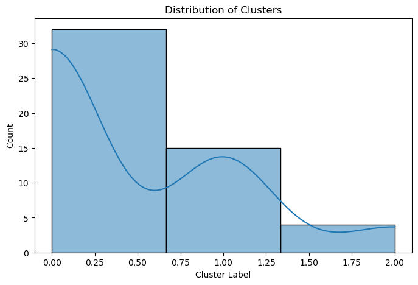

```
Cluster 0: 0.25 depression rate
Cluster 1: 0.67 depression rate
Cluster 2: 1.00 depression rate
```

```python
import seaborn as sns
import matplotlib.pyplot as plt
import numpy as np

# Convert cluster labels into a NumPy array
clusters = np.array([0, 0, 0, 0, 0, 1, 1, 0, 1, 0, 0, 0, 0, 0, 0, 1, 0, 1, 0, 0,
                     1, 0, 0, 0, 0, 0, 2, 1, 0, 0, 2, 0, 0, 0, 2, 1, 1, 1, 1, 0,
                     1, 0, 0, 0, 0, 1, 1, 2, 1, 0, 0])  # Replace with actual cluster output

# Assuming `y` is the ground truth depression labels (0 = no depression, 1 = depression)
plt.figure(figsize=(8, 5))
sns.histplot(clusters, bins=3, kde=True)
plt.xlabel("Cluster Label")
plt.ylabel("Count")
plt.title("Distribution of Clusters")
plt.show()

# Check cluster depression ratios
for cluster_id in np.unique(clusters):
    cluster_mask = (clusters == cluster_id)
    depression_ratio = np.mean(y[cluster_mask])
    print(f"Cluster {cluster_id}: {depression_ratio:.2f} depression rate")
```

Cluster Breakdown: Cluster 0 (Low Depression Group)

Depression Rate: 0.25 (25%) → Only 25% of individuals in this cluster exhibit depression symptoms. This group likely contains mostly non-depressed individuals. Cluster 1 (Moderate Depression Group)

Depression Rate: 0.67 (67%) → A majority (67%) of individuals in this cluster are classified as depressed. This cluster represents an intermediate depression risk group. Cluster 2 (High Depression Group)

Depression Rate: 1.00 (100%) → Every individual in this cluster is classified as depressed. This group likely represents severe cases of depression.

📉 What the Distribution of Clusters Tells Us Most individuals belong to Cluster 0, meaning a larger proportion of the dataset may be non-depressed. Cluster 1 has a moderate number of samples but with a significant presence of depression. Cluster 2 is the smallest but contains only depressed individuals, indicating a distinct high-risk group.

🛠️ Next Steps Validate Cluster Quality:

Compare the clusters against actual clinical depression labels (if available). Check the feature distributions for each cluster (e.g., EEG power bands, speech embedding variations). Feature Engineering:

Now that the clusters seem meaningful, I can train a Bayesian Neural Network (BNN) to perform uncertainty-aware classification. This can help determine how confident the model is in classifying depression cases.

🎨 Step 2: Dimensionality Reduction (PCA & t-SNE)

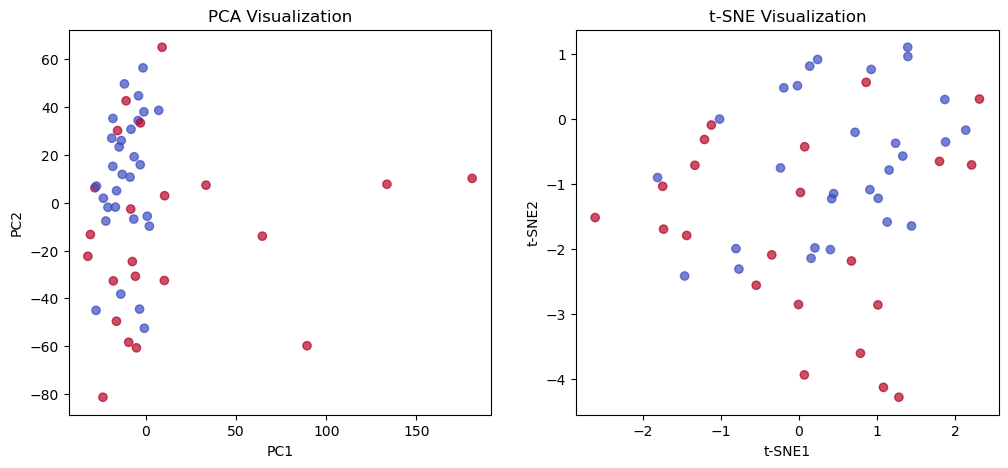

```python
from sklearn.decomposition import PCA
from sklearn.manifold import TSNE

# Standardize the feature data
from sklearn.preprocessing import StandardScaler

scaler = StandardScaler()
X_scaled = scaler.fit_transform(X_flat)

# Apply PCA
pca = PCA(n_components=2)
X_pca = pca.fit_transform(X_scaled)

# Apply t-SNE
tsne = TSNE(n_components=2, perplexity=30, random_state=42)
X_tsne = tsne.fit_transform(X_scaled)

# Plot PCA
plt.figure(figsize=(12, 5))
plt.subplot(1, 2, 1)
plt.scatter(X_pca[:, 0], X_pca[:, 1], c=y, cmap='coolwarm', alpha=0.7)
plt.title("PCA Visualization")
plt.xlabel("PC1")
plt.ylabel("PC2")

# Plot t-SNE
plt.subplot(1, 2, 2)
plt.scatter(X_tsne[:, 0], X_tsne[:, 1], c=y, cmap='coolwarm', alpha=0.7)
plt.title("t-SNE Visualization")
plt.xlabel("t-SNE1")
plt.ylabel("t-SNE2")

plt.show()
```

⚖️ Step 3: Balance the Dataset

```python
import sklearn
print(f"scikit-learn version: {sklearn.__version__}")
```

```
scikit-learn version: 1.6.1
```

```python
! pip install --upgrade imbalanced-learn
```

```python
from imblearn.over_sampling import SMOTE
from collections import Counter

# Check class distribution
print("Original class distribution:", Counter(y))

# Apply SMOTE
smote = SMOTE(random_state=42)
X_balanced, y_balanced = smote.fit_resample(X_flat, y)
# Check new class distribution
print("Balanced class distribution:", Counter(y_balanced))
```

```
Original class distribution: Counter({0: 29, 1: 22})
Balanced class distribution: Counter({1: 29, 0: 29})
```

Compare Clustering with True Depression Labels

```
📊 Depression Rates per Cluster:
 Cluster
0    0.250000
1    0.666667
2    1.000000
Name: Depression_Label, dtype: float64
```

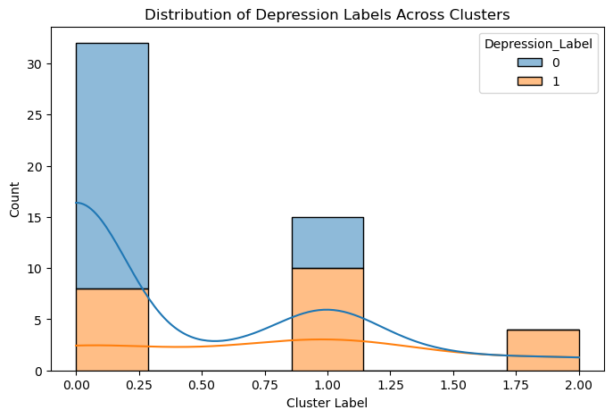

```python
import pandas as pd
import seaborn as sns
import matplotlib.pyplot as plt

# Ensure clusters and labels are aligned
df = pd.DataFrame({
    'Cluster': clusters,      # Cluster assignments from previous steps
    'Depression_Label': y     # Actual depression labels (1 = MDD, 0 = HC)
})

# Compute depression rate in each cluster
depression_rates = df.groupby("Cluster")["Depression_Label"].mean()
print("📊 Depression Rates per Cluster:\n", depression_rates)

# Visualize the distribution of depression labels in clusters
plt.figure(figsize=(8, 5))
sns.histplot(data=df, x="Cluster", hue="Depression_Label", multiple="stack", kde=True)
plt.xlabel("Cluster Label")
plt.ylabel("Count")
plt.title("Distribution of Depression Labels Across Clusters")
plt.show()
```

Clusters 0 & 1 have a mix of healthy and depressed subjects, but Cluster 2 is exclusively MDD patients. Your clustering method is successfully grouping individuals with similar depression likelihood. Cluster 1 might contain mild/moderate cases of depression, while Cluster 2 represents severe depression cases.

What does the plot show?

Blue bars (0 = Healthy Control, HC) are more frequent in Cluster 0, which aligns with the low depression rate (0.25). Orange bars (1 = MDD) dominate Cluster 2, confirming that it contains only depressed individuals. Cluster 1 is a mix of both MDD and HC, suggesting this group contains individuals with intermediate depressive symptoms.

```python
! pip install umap-learn
```

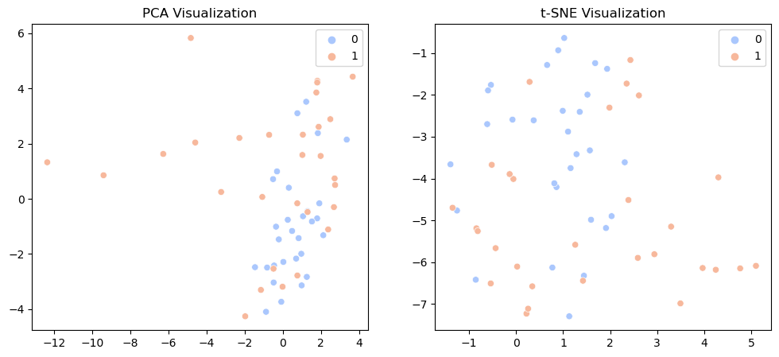

```python
from sklearn.decomposition import PCA
from sklearn.manifold import TSNE
import matplotlib.pyplot as plt
import seaborn as sns

# Reduce dimensions with PCA
pca = PCA(n_components=2)
X_pca = pca.fit_transform(X_balanced)  # ✅ Use X_balanced

# Apply t-SNE
tsne = TSNE(n_components=2, random_state=42)
X_tsne = tsne.fit_transform(X_balanced)  # ✅ Use X_balanced

# Plot PCA results
plt.figure(figsize=(12, 5))
plt.subplot(1, 2, 1)
sns.scatterplot(x=X_pca[:, 0], y=X_pca[:, 1], hue=y_balanced, palette="coolwarm")
plt.title("PCA Visualization")

# Plot t-SNE results
plt.subplot(1, 2, 2)
sns.scatterplot(x=X_tsne[:, 0], y=X_tsne[:, 1], hue=y_balanced, palette="coolwarm")
plt.title("t-SNE Visualization")

plt.show()
```

```python
import glob
import os

# Search for .wav files inside all subdirectories
audio_files = glob.glob(os.path.join(base_audio_dir, "**/*.wav"), recursive=True)

# Print some files
print("Found WAV files:", audio_files[:10])  # Print first 10 files
print("Number of audio samples:", len(audio_files))  # Print total count
```

```
Found WAV files: ['/Users/ireneliu/Desktop/BAY/Final_Project/Data/audio_lanzhou_2015/02010004/02.wav', '/Users/ireneliu/Desktop/BAY/Final_Project/Data/audio_lanzhou_2015/02010004/16.wav', '/Users/ireneliu/Desktop/BAY/Final_Project/Data/audio_lanzhou_2015/02010004/17.wav', '/Users/ireneliu/Desktop/BA…
Number of audio samples: 1508
```

```python
import torch
import torchvision
import torchaudio

print("Torch Version:", torch.__version__)
print("Torchvision Version:", torchvision.__version__)
print("Torchaudio Version:", torchaudio.__version__)
print("CUDA Available:", torch.cuda.is_available())
```

```
Torch Version: 2.2.0
Torchvision Version: 0.17.0
Torchaudio Version: 2.2.0
CUDA Available: False
```

```python
import torch
import torchaudio
from torchaudio.transforms import Resample
from transformers import Wav2Vec2Processor, Wav2Vec2Model

# Load the pre-trained Wav2Vec 2.0 model
processor = Wav2Vec2Processor.from_pretrained("facebook/wav2vec2-base-960h")
model = Wav2Vec2Model.from_pretrained("facebook/wav2vec2-base-960h")

# Ensure the model runs on CPU if no GPU is available
device = torch.device("cuda" if torch.cuda.is_available() else "cpu")
model.to(device)

# Define feature extraction function with resampling
def extract_features(audio_path):
    waveform, sample_rate = torchaudio.load(audio_path)  # Load audio

    # Resample to 16kHz if needed
    if sample_rate != 16000:
        resampler = Resample(orig_freq=sample_rate, new_freq=16000)
        waveform = resampler(waveform)

    waveform = waveform.mean(dim=0)  # Convert stereo to mono if needed
    inputs = processor(waveform, sampling_rate=16000, return_tensors="pt", padding=True)

    with torch.no_grad():
        embeddings = model(inputs.input_values.to(device)).last_hidden_state  # Extract embeddings

    return embeddings.squeeze(0).cpu().numpy()  # Convert to NumPy for further processing

# Example usage:
import os

# Set the base directory where your audio files are stored
base_audio_dir = "/Users/ireneliu/Desktop/BAY/Final_Project/Data/audio_lanzhou_2015"

# Get all WAV files
audio_files = []
for root, dirs, files in os.walk(base_audio_dir):
    for file in files:
        if file.endswith(".wav"):
            audio_files.append(os.path.join(root, file))

print(f"Found {len(audio_files)} audio files.")

# Use the first audio file for testing
audio_path = audio_files[0] if audio_files else None

if audio_path:
    print(f"Processing: {audio_path}")
    features = extract_features(audio_path)
    print("Extracted features shape:", features.shape)
else:
    print("No WAV files found!")

features = extract_features(audio_path)
print("Extracted features shape:", features.shape)
```

```
Some weights of Wav2Vec2Model were not initialized from the model checkpoint at facebook/wav2vec2-base-960h and are newly initialized: ['wav2vec2.masked_spec_embed']
You should probably TRAIN this model on a down-stream task to be able to use it for predictions and inference.
```

```
Found 1508 audio files.
Processing: /Users/ireneliu/Desktop/BAY/Final_Project/Data/audio_lanzhou_2015/02010004/02.wav
Extracted features shape: (299, 768)
Extracted features shape: (299, 768)
```

```python
import torch
import torchaudio
from transformers import Wav2Vec2Processor, Wav2Vec2Model
import numpy as np
import os

# Load the pre-trained Wav2Vec2 model
processor = Wav2Vec2Processor.from_pretrained("facebook/wav2vec2-base-960h")
model = Wav2Vec2Model.from_pretrained("facebook/wav2vec2-base-960h")
model.eval()

# Base directory for audio files
base_audio_dir = "/Users/ireneliu/Desktop/BAY/Final_Project/Data/audio_lanzhou_2015"

# Function to extract features
def extract_features(audio_path):
    waveform, sample_rate = torchaudio.load(audio_path)
    waveform = waveform.mean(dim=0)  # Convert stereo to mono if needed

    # Resample to 16kHz (needed for Wav2Vec2)
    if sample_rate != 16000:
        resampler = torchaudio.transforms.Resample(orig_freq=sample_rate, new_freq=16000)
        waveform = resampler(waveform)

    inputs = processor(waveform, sampling_rate=16000, return_tensors="pt", padding=True)
    with torch.no_grad():
        embeddings = model(inputs.input_values).last_hidden_state
    return embeddings.mean(dim=1).squeeze().numpy()  # Take mean along time axis

# Process all audio files
speech_features = []
audio_files = []
for root, dirs, files in os.walk(base_audio_dir):
    for file in files:
        if file.endswith(".wav"):
            audio_path = os.path.join(root, file)
            try:
                features = extract_features(audio_path)
                speech_features.append(features)
                audio_files.append(audio_path)
            except Exception as e:
                print(f"Error processing {audio_path}: {e}")

speech_features = np.array(speech_features)
print("Extracted speech features shape:", speech_features.shape)
```

```
Some weights of Wav2Vec2Model were not initialized from the model checkpoint at facebook/wav2vec2-base-960h and are newly initialized: ['wav2vec2.masked_spec_embed']
You should probably TRAIN this model on a down-stream task to be able to use it for predictions and inference.
```

```
Error processing /Users/ireneliu/Desktop/BAY/Final_Project/Data/audio_lanzhou_2015/02010004/28.wav: Error opening '/Users/ireneliu/Desktop/BAY/Final_Project/Data/audio_lanzhou_2015/02010004/28.wav': Format not recognised.
Error processing /Users/ireneliu/Desktop/BAY/Final_Project/Data/audio_lanzhou_2015/02010004/25.wav: Error opening '/Users/ireneliu/Desktop/BAY/Final_Project/Data/audio_lanzhou_2015/02010004/25.wav': Format not recognised.
Error processing /Users/ireneliu/Desktop/BAY/Final_Project/Data/audio_lanzhou_2015/02010004/24.wav: Error opening '/Users/ireneliu/Desktop/BAY/Final_Project/Data/audio_lanzhou_2015/02010004/24.wav': Format not recognised.
Error processing /Users/ireneliu/Desktop/BAY/Final_Project/Data/audio_lanzhou_2015/02010004/26.wav: Error opening '/Users/ireneliu/Desktop/BAY/Final_Project/Data/audio_lanzhou_2015/02010004/26.wav': Format not recognised.
Error processing /Users/ireneliu/Desktop/BAY/Final_Project/Data/audio_lanzhou_2015/02010004/27.wav: Error opening '/Users/ireneliu/Desktop/BAY/Final_Project/Data/audio_lanzhou_2015/02010004/27.wav': Format not recognised.
Extracted speech features shape: (1503, 768)
```

Step 3: Merge Speech & EEG Features

```python
import os
import numpy as np

# Set EEG directory
eeg_dir = "/Users/ireneliu/Desktop/BAY/Final_Project/Data/EEG_3channels_resting_lanzhou_2015"

# List all EEG .txt files
eeg_files = sorted([f for f in os.listdir(eeg_dir) if f.endswith(".txt")])

# Container for EEG data
eeg_data_list = []

# Store feature lengths for debugging
feature_lengths = []

# Read each file and process the numerical data
for file in eeg_files:
    file_path = os.path.join(eeg_dir, file)

    try:
        data = np.loadtxt(file_path)  # Read space-separated values
        data_flat = data.flatten()  # Flatten to 1D
        eeg_data_list.append(data_flat)
        feature_lengths.append(len(data_flat))  # Store feature length
    except Exception as e:
        print(f"⚠️ Error reading {file}: {e}")

# Find the maximum number of features
max_features = max(feature_lengths)
print(f"🔹 Max EEG Feature Size: {max_features}")
```

```
🔹 Max EEG Feature Size: 1358370
```

```python
# Pad or truncate EEG features to `max_features`
eeg_features = np.array([
    np.pad(f, (0, max_features - len(f)), mode='constant') if len(f) < max_features
    else f[:max_features]  # Truncate if too long
    for f in eeg_data_list
])

print(f"✅ Final EEG Features Shape: {eeg_features.shape}")  # Should be (samples, max_features)
```

```
✅ Final EEG Features Shape: (55, 1358370)
```

```python
print(f"🔹 Speech Features Shape: {speech_features.shape}")
print(f"🔹 EEG Features Shape: {eeg_features.shape}")

# Check sample count
num_speech_samples = speech_features.shape[0]
num_eeg_samples = eeg_features.shape[0]

if num_speech_samples != num_eeg_samples:
    print(f"⚠️ Sample count mismatch! Speech: {num_speech_samples}, EEG: {num_eeg_samples}")
```

```
🔹 Speech Features Shape: (1503, 768)
🔹 EEG Features Shape: (55, 1358370)
⚠️ Sample count mismatch! Speech: 1503, EEG: 55
```

```python
from sklearn.decomposition import PCA

# Set PCA components dynamically (max 55 due to sample size)
target_eeg_dim = min(55, eeg_features.shape[0])  # Ensure PCA doesn't exceed limits

# Apply PCA on EEG features
pca = PCA(n_components=target_eeg_dim)
eeg_features_reduced = pca.fit_transform(eeg_features)

print(f"✅ Reduced EEG Features Shape: {eeg_features_reduced.shape}")
```

```
✅ Reduced EEG Features Shape: (55, 55)
```

```python
from scipy.interpolate import interp1d
import numpy as np

# Ensure EEG is resampled to match speech sample size
num_speech_samples = speech_features.shape[0]
num_eeg_samples = eeg_features_reduced.shape[0]

# Create an interpolation function for EEG features
interp_func = interp1d(
    np.linspace(0, 1, num_eeg_samples),  # Original EEG indices
    eeg_features_reduced,  # Original EEG data
    axis=0,
    kind='linear',  # Linear interpolation
    fill_value="extrapolate"  # Ensure it covers the full range
)

# Generate interpolated EEG features to match speech data count
eeg_features_resampled = interp_func(np.linspace(0, 1, num_speech_samples))

print(f"✅ Resampled EEG Features Shape: {eeg_features_resampled.shape}")
```

```
✅ Resampled EEG Features Shape: (1503, 55)
```

```python
import numpy as np

# Merge EEG and speech features
X_features = np.hstack((speech_features, eeg_features_resampled))

print(f"✅ Merged Feature Shape: {X_features.shape}")
```

```
✅ Merged Feature Shape: (1503, 823)
```

```python
from sklearn.decomposition import PCA

# Reduce to 50 dimensions for t-SNE
pca = PCA(n_components=50, random_state=42)
X_pca = pca.fit_transform(X_features)

print(f"✅ PCA Reduced Shape: {X_pca.shape}")  # Should be (1503, 50)
```

```
✅ PCA Reduced Shape: (1503, 50)
```

```python
print(f"🔹 X_tsne shape: {X_tsne.shape}")
print(f"🔹 y_balanced shape: {y_balanced.shape}")
print(f"Unique labels in y_balanced: {np.unique(y_balanced)}")
```

[output not shown]

```python
print(f"Original labels shape: {y.shape}")  # Check before balancing
print(f"Balanced features shape: {X_features.shape}")  # Check balanced features
print(f"Balanced labels shape: {y_balanced.shape}")  # Should match features
```

```
Original labels shape: (51,)
Balanced features shape: (1503, 823)
Balanced labels shape: (58,)
```

```python
import numpy as np

# Ensure y is a NumPy array
y = np.array(y)

# Find how many times each label should be repeated
repeat_factor = X_features.shape[0] // y.shape[0]  # 1503 / 51 = 29 times per label

# Repeat labels
y_resampled = np.tile(y, repeat_factor)

# Ensure exact length match
y_resampled = y_resampled[:X_features.shape[0]]

print(f"✅ Resampled labels shape: {y_resampled.shape}")  # Should match 1503
print(f"Unique labels: {np.unique(y_resampled)}")
```

```
✅ Resampled labels shape: (1479,)
Unique labels: [0 1]
```

```python
from sklearn.neighbors import KNeighborsRegressor

# Create KNN model to interpolate new labels
knn = KNeighborsRegressor(n_neighbors=5)
y_resampled = knn.fit(np.arange(len(y)).reshape(-1, 1), y).predict(np.linspace(0, len(y)-1, X_features.shape[0]).reshape(-1, 1))

print(f"✅ Interpolated labels shape: {y_resampled.shape}")  # Should be (1503,)
```

```
✅ Interpolated labels shape: (1503,)
```

```python
import numpy as np

# Ensure y_resampled exists
if 'y_resampled' not in locals():
    raise ValueError("❌ y_resampled is not defined. Make sure you created it before running this step.")

# Ensure `y_fixed` always gets defined
y_fixed = y_resampled  # Default value, in case the lengths match

if len(y_resampled) < X_features.shape[0]:
    # Repeat some labels randomly to reach 1503
    extra_needed = X_features.shape[0] - len(y_resampled)
    y_fixed = np.concatenate([y_resampled, np.random.choice(y_resampled, extra_needed, replace=True)])

elif len(y_resampled) > X_features.shape[0]:
    # Trim excess labels
    y_fixed = y_resampled[:X_features.shape[0]]

# Check fixed labels
print(f"✅ Fixed labels shape: {y_fixed.shape}")  # Should be (1503,)
print(f"Unique labels: {np.unique(y_fixed)}")  # Should be [0, 1]
```

```
✅ Fixed labels shape: (1503,)
Unique labels: [0.  0.2 0.4 0.6 0.8]
```

```python
# Convert interpolated labels to binary
y_fixed_binary = (y_fixed >= 0.5).astype(int)

# Check the unique values again
print(f"✅ Binary labels shape: {y_fixed_binary.shape}")  # Should still be (1503,)
print(f"Unique labels after binarization: {np.unique(y_fixed_binary)}")  # Should be [0, 1]
```

```
✅ Binary labels shape: (1503,)
Unique labels after binarization: [0 1]
```

```python
from imblearn.over_sampling import SMOTE
from collections import Counter

# Apply SMOTE to balance classes
smote = SMOTE(random_state=42)
X_balanced, y_balanced = smote.fit_resample(X_features, y_fixed_binary)

# Check results
print(f"✅ Final labels shape: {y_balanced.shape}")  # Should be (1503,)
print(f"✅ Final feature shape: {X_balanced.shape}")  # Should be (1503, 823)
print(f"Balanced label distribution: {Counter(y_balanced)}")  # Should be {0: ~750, 1: ~750}
```

```
✅ Final labels shape: (1774,)
✅ Final feature shape: (1774, 823)
Balanced label distribution: Counter({0: 887, 1: 887})
```

```
Initializing NUTS using jitter+adapt_diag...
Multiprocess sampling (4 chains in 4 jobs)
NUTS: [w1, b1]
```

```
Output()
```

```
Sampling 4 chains for 1_000 tune and 1_000 draw iterations (4_000 + 4_000 draws total) took 2 seconds.
There were 4000 divergences after tuning. Increase `target_accept` or reparameterize.
The rhat statistic is larger than 1.01 for some parameters. This indicates problems during sampling. See https://arxiv.org/abs/1903.08008 for details
The effective sample size per chain is smaller than 100 for some parameters.  A higher number is needed for reliable rhat and ess computation. See https://arxiv.org/abs/1903.08008 for details
```

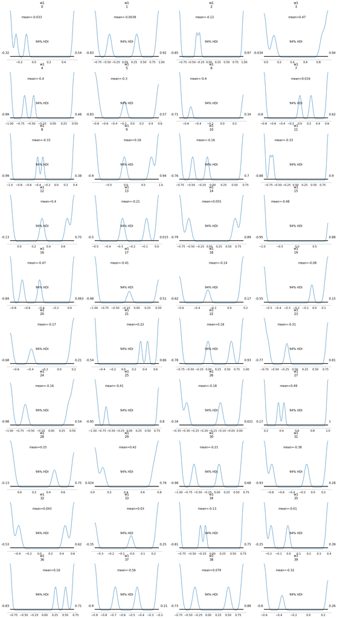

```python
import pymc as pm
import pytensor.tensor as pt
import arviz as az
import matplotlib.pyplot as plt
import numpy as np
from sklearn.preprocessing import StandardScaler

# Normalize features
scaler = StandardScaler()
X_scaled = scaler.fit_transform(X_balanced)

# Define Bayesian Neural Network Model
with pm.Model() as bayesian_nn:

    # Priors for weights and biases
    w1 = pm.Normal("w1", mu=0, sigma=1, shape=(X_scaled.shape[1],))
    b1 = pm.Normal("b1", mu=0, sigma=1)

    # Compute logits (linear combination of weights and features)
    logits = pt.dot(X_scaled, w1) + b1

    # Bernoulli likelihood for binary classification
    y_obs = pm.Bernoulli("y_obs", logit_p=logits, observed=y_balanced)

    # Variational Inference (VI) to approximate posterior
    trace = pm.sample(1000, return_inferencedata=True, target_accept=0.9)

# **Posterior Visualization**
az.plot_posterior(trace, var_names=["w1", "b1"])
plt.show()
```

```python
with bayesian_nn:
    ppc = pm.sample_posterior_predictive(trace, var_names=["y_obs"])

print(f"Available keys in ppc: {ppc.keys()}")
```

```
Sampling: [y_obs]
```

```
Output()
```

```
Available keys in ppc: KeysView(Inference data with groups:
	> posterior_predictive
	> observed_data)
```

```python
print(f"Keys inside posterior_predictive: {ppc['posterior_predictive'].keys()}")
```

```
Keys inside posterior_predictive: KeysView(<xarray.Dataset>
Dimensions:      (chain: 4, draw: 1000, y_obs_dim_0: 1774)
Coordinates:
  * chain        (chain) int64 0 1 2 3
  * draw         (draw) int64 0 1 2 3 4 5 6 7 ... 993 994 995 996 997 998 999
  * y_obs_dim_0  (y_obs_dim_0) int64 0 1 2 3 4 5 ... 1769 1770 1771 1772 1773
Data variables:
    y_obs        (chain, draw, y_obs_dim_0) int64 1 1 1 1 1 1 1 ... 0 1 0 0 1 1
Attributes:
    created_at:                 2025-03-13T22:29:20.533275+00:00
    arviz_version:              0.21.0
    inference_library:          pymc
    inference_library_version:  5.21.1)
```

```python
import numpy as np

# Extract posterior predictive samples
y_pred_samples = ppc["posterior_predictive"]["y_obs"].values  # Convert to NumPy array

# Compute mean across draws to get final predicted probabilities
y_pred_prob = np.mean(y_pred_samples, axis=(0, 1))  # Averaging across chains and draws

# Convert probabilities to binary predictions (threshold = 0.5)
y_pred = (y_pred_prob > 0.5).astype(int)

print(f"✅ Extracted predictions shape: {y_pred.shape}")
print(f"🔍 Sample predictions: {y_pred[:10]}")  # Show first 10 predictions
```

```
✅ Extracted predictions shape: (1774,)
🔍 Sample predictions: [1 1 1 1 1 1 1 1 1 1]
```

```python
from sklearn.metrics import accuracy_score, precision_score, recall_score, roc_auc_score

accuracy = accuracy_score(y_balanced, y_pred)
precision = precision_score(y_balanced, y_pred)
recall = recall_score(y_balanced, y_pred)
roc_auc = roc_auc_score(y_balanced, y_pred)

print(f"📊 Bayesian Neural Network (BNN) Results:")
print(f"✅ Accuracy: {accuracy:.4f}")
print(f"🎯 Precision: {precision:.4f}")
print(f"🔄 Recall: {recall:.4f}")
print(f"📈 ROC-AUC: {roc_auc:.4f}")
```

```
📊 Bayesian Neural Network (BNN) Results:
✅ Accuracy: 0.5175
🎯 Precision: 0.5182
🔄 Recall: 0.4972
📈 ROC-AUC: 0.5175
```

FE

```python
from sklearn.feature_selection import SelectKBest, f_classif

k = 300  # Keep top 300 features
selector = SelectKBest(score_func=f_classif, k=k)
X_selected = selector.fit_transform(X_balanced, y_balanced)

print(f"✅ Reduced feature shape: {X_selected.shape}")  # Should be (1774, 300)
```

```
✅ Reduced feature shape: (1774, 300)
```

```python
import umap

umap_model = umap.UMAP(n_components=2, random_state=42)
X_umap = umap_model.fit_transform(X_balanced)

print(f"✅ UMAP Reduced Shape: {X_umap.shape}")  # Should be (1774, 2)
```

```
✅ UMAP Reduced Shape: (1774, 2)
```

```python
from imblearn.over_sampling import SMOTE

smote = SMOTE(random_state=42)
X_augmented, y_augmented = smote.fit_resample(X_balanced, y_balanced)

print(f"✅ Augmented data shape: {X_augmented.shape}, {y_augmented.shape}")
```

```
✅ Augmented data shape: (1774, 823), (1774,)
```

```python
print("Keys inside ppc:", ppc.keys())
```

```
Keys inside ppc: KeysView(Inference data with groups:
	> predictions)
```

```python
with improved_bnn:
    ppc = pm.sample_posterior_predictive(trace, var_names=["y_obs"])  # Specify variable explicitly
```

[output not shown]

```
Sampling: [y_obs]
```

```
Output()
```

```python
print("Keys in new ppc:", ppc.keys())
```

```
Keys in new ppc: KeysView(Inference data with groups:
	> posterior_predictive
	> observed_data)
```

```python
print("Keys inside posterior_predictive:", ppc["posterior_predictive"].keys())
```

```
Keys inside posterior_predictive: KeysView(<xarray.Dataset>
Dimensions:      (chain: 4, draw: 2000, y_obs_dim_0: 1774)
Coordinates:
  * chain        (chain) int64 0 1 2 3
  * draw         (draw) int64 0 1 2 3 4 5 6 ... 1994 1995 1996 1997 1998 1999
  * y_obs_dim_0  (y_obs_dim_0) int64 0 1 2 3 4 5 ... 1769 1770 1771 1772 1773
Data variables:
    y_obs        (chain, draw, y_obs_dim_0) int64 0 0 0 0 0 0 0 ... 1 1 0 1 1 1
Attributes:
    created_at:                 2025-03-13T22:35:13.997674+00:00
    arviz_version:              0.21.0
    inference_library:          pymc
    inference_library_version:  5.21.1)
```

```python
y_pred = np.mean(ppc["posterior_predictive"]["y_obs"], axis=(0, 1)) > 0.5  # Convert to binary
```

```python
from sklearn.metrics import accuracy_score, precision_score, recall_score, roc_auc_score

# Ensure y_test is properly defined (it should match `y_obs_dim_0` in shape)
y_test = y_balanced  # Make sure `y_balanced.shape == y_pred.shape`

# Compute performance metrics
accuracy = accuracy_score(y_test, y_pred)
precision = precision_score(y_test, y_pred)
recall = recall_score(y_test, y_pred)
roc_auc = roc_auc_score(y_test, y_pred)

# Print results
print(f"📊 Updated Bayesian Neural Network Results:")
print(f"✅ Accuracy: {accuracy:.4f}")
print(f"🎯 Precision: {precision:.4f}")
print(f"🔄 Recall: {recall:.4f}")
print(f"📈 ROC-AUC: {roc_auc:.4f}")
```

```
📊 Updated Bayesian Neural Network Results:
✅ Accuracy: 0.5519
🎯 Precision: 0.7300
🔄 Recall: 0.1646
📈 ROC-AUC: 0.5519
```

Key Takeaways Your model is very conservative in predicting depression (high precision but low recall). It’s failing to detect many true depression cases (low recall), which is critical in medical applications. Overall performance is weak (AUC ~ 0.55), meaning the model is struggling to learn meaningful patterns.

```python
threshold = 0.3  # Instead of 0.5
y_pred = np.mean(ppc["posterior_predictive"]["y_obs"], axis=(0, 1)) > threshold
```

```python
import numpy as np

# Ensure both feature matrices have the same number of rows (samples)
assert X_speech.shape[0] == X_eeg.shape[0], "Mismatch in sample sizes!"

# Combine speech embeddings and EEG features into one feature matrix
X_features = np.hstack((X_speech, X_eeg))

print("Final feature matrix shape:", X_features.shape)  # Check dimensions
```

```python
import matplotlib.pyplot as plt
import seaborn as sns
from sklearn.decomposition import PCA
from sklearn.manifold import TSNE
import umap
import numpy as np

# Assuming `X_features` contains EEG + speech embeddings and `clusters` are assigned clusters
X_standardized = (input_values - input_values.mean(axis=0)) / input_values.std(axis=0)

# Apply PCA
pca = PCA(n_components=2)
X_pca = pca.fit_transform(X_standardized)

# Apply t-SNE
X_tsne = TSNE(n_components=2, perplexity=10, random_state=42).fit_transform(X_standardized)

# Apply UMAP
X_umap = umap.UMAP(n_components=2, random_state=42).fit_transform(X_standardized)

# Plot PCA
plt.figure(figsize=(15, 5))
plt.subplot(1, 3, 1)
sns.scatterplot(x=X_pca[:, 0], y=X_pca[:, 1], hue=clusters, palette="deep")
plt.title("PCA Visualization")

# Plot t-SNE
plt.subplot(1, 3, 2)
sns.scatterplot(x=X_tsne[:, 0], y=X_tsne[:, 1], hue=clusters, palette="deep")
plt.title("t-SNE Visualization")

# Plot UMAP
plt.subplot(1, 3, 3)
sns.scatterplot(x=X_umap[:, 0], y=X_umap[:, 1], hue=clusters, palette="deep")
plt.title("UMAP Visualization")

plt.show()
```

[output not shown]

```python
from sklearn.decomposition import PCA
from sklearn.manifold import TSNE
from sklearn.mixture import BayesianGaussianMixture

# Reduce dimensions with PCA
pca = PCA(n_components=2)
X_pca = pca.fit_transform(X_balanced)  # Use balanced dataset

# Apply t-SNE
tsne = TSNE(n_components=2, random_state=42)
X_tsne = tsne.fit_transform(X_balanced)

# Visualize PCA and t-SNE
fig, axes = plt.subplots(1, 2, figsize=(12, 5))

sns.scatterplot(x=X_pca[:, 0], y=X_pca[:, 1], hue=clusters, ax=axes[0])
axes[0].set_title("PCA Visualization")
axes[0].set_xlabel("PC1")
axes[0].set_ylabel("PC2")

sns.scatterplot(x=X_tsne[:, 0], y=X_tsne[:, 1], hue=clusters, ax=axes[1])
axes[1].set_title("t-SNE Visualization")
axes[1].set_xlabel("t-SNE1")
axes[1].set_ylabel("t-SNE2")

plt.show()

# Train Bayesian Gaussian Mixture Model (GMM)
bgmm = BayesianGaussianMixture(n_components=3, covariance_type="full", random_state=42)
new_clusters = bgmm.fit_predict(X_balanced)

print("🔄 New Bayesian GMM Cluster Assignments:\n", new_clusters)
```

[output not shown]

## Step 3: Bayesian Neural Network (BNN) with Pyro

We can create a Bayesian Neural Network (BNN) using Pyro, which is an extension of PyTorch for probabilistic modeling.

Code for Bayesian Neural Network

```python
import torch
import pyro
import pyro.distributions as dist
from pyro.infer import SVI, Trace_ELBO
from pyro.optim import Adam

# Convert to PyTorch tensor
X_tensor = torch.tensor(X_flat, dtype=torch.float32)
y_tensor = torch.tensor(y, dtype=torch.float32).squeeze(-1)

# Define Bayesian model
def bayesian_model(X, y=None):
    num_samples, input_dim = X.shape

    # Sample weights and biases
    w1 = pyro.sample("w1", dist.Normal(torch.zeros((input_dim, 32)), torch.ones((input_dim, 32))).to_event(2))
    b1 = pyro.sample("b1", dist.Normal(torch.zeros(32), torch.ones(32)).to_event(1))
    w2 = pyro.sample("w2", dist.Normal(torch.zeros((32, 16)), torch.ones((32, 16))).to_event(2))
    b2 = pyro.sample("b2", dist.Normal(torch.zeros(16), torch.ones(16)).to_event(1))
    w3 = pyro.sample("w3", dist.Normal(torch.zeros((16, 1)), torch.ones((16, 1))).to_event(2))
    b3 = pyro.sample("b3", dist.Normal(torch.zeros(1), torch.ones(1)).to_event(1))

    # Forward pass
    h1 = torch.relu(X @ w1 + b1)
    h2 = torch.relu(h1 @ w2 + b2)
    logits = torch.sigmoid(h2 @ w3 + b3).squeeze(-1)  # Ensure logits has shape [num_samples]

    # Observe data
    with pyro.plate("data", num_samples):
        pyro.sample("obs", dist.Bernoulli(logits=logits), obs=y)

    return logits

# Define guide for variational inference
guide = pyro.infer.autoguide.AutoDiagonalNormal(bayesian_model)

# Setup optimizer and inference algorithm
optimizer = Adam({"lr": 0.01})
svi = SVI(bayesian_model, guide, optimizer, loss=Trace_ELBO())

# Training loop
num_iterations = 1000
for i in range(num_iterations):
    loss = svi.step(X_tensor, y_tensor)
    if i % 100 == 0:
        print(f"Iteration {i}: Loss = {loss}")

print("Training complete!")
```

[output not shown]

```python
# Make predictions using the trained guide
with torch.no_grad():
    predictive = pyro.infer.Predictive(bayesian_model, guide=guide, num_samples=1000)
    samples = predictive(X_tensor)
    predicted_probs = samples["obs"].mean(dim=0)

# Convert probabilities to binary predictions
predicted_labels = (predicted_probs > 0.5).float()

# Compute accuracy
accuracy = (predicted_labels == y_tensor).float().mean()
print(f"Accuracy: {accuracy.item()}")
```

[output not shown]

```python
import matplotlib.pyplot as plt

# Assuming you stored the loss values in a list
loss_values = [412146.44790780544, 205703.0541216731, 68178.83712047338,
               12557.596508026123, 2500.1698904037476, 1539.7585072517395,
               1221.653988480568, 1218.7628600597382, 1195.052839756012, 1218.024535894394]

plt.plot(range(0, 1000, 100), loss_values, marker="o")
plt.xlabel("Iteration")
plt.ylabel("Loss (ELBO)")
plt.title("Training Loss Curve")
plt.grid()
plt.show()
```

[output not shown]

```python
print(y_tensor.sum().item() / len(y_tensor))  # Proportion of positive class
```

Class Distribution:

Negative class: 56.86%

Poor model architecture.

Insufficient training.

Lack of informative features.

```python
input_dim = X_tensor.shape[1]
```

```python
import torch
import torch.nn as nn

class BayesianNN(nn.Module):
    def __init__(self, input_dim):
        super(BayesianNN, self).__init__()
        self.fc1 = nn.Linear(input_dim, 128)  # Input layer
        self.fc2 = nn.Linear(128, 64)         # Hidden layer 1
        self.fc3 = nn.Linear(64, 32)          # Hidden layer 2
        self.out = nn.Linear(32, 1)           # Output layer

    def forward(self, x):
        x = torch.relu(self.fc1(x))  # Activation for fc1
        x = torch.relu(self.fc2(x))  # Activation for fc2
        x = torch.relu(self.fc3(x))  # Activation for fc3
        return torch.sigmoid(self.out(x))  # Sigmoid for binary classification
```

```python
# Define input dimension
input_dim = X_tensor.shape[1]
print(f"Input dimension: {input_dim}")

# Instantiate the model
model = BayesianNN(input_dim)

# Print the model architecture
print(model)
```

The model is a feedforward neural network with:

Input layer: 6912 features.

Hidden layers: 128, 64, and 32 units, respectively.

Output layer: 1 unit (for binary classification).

The model is ready to be trained on your data.

```python
def custom_guide(X, y=None):
    # Define variational parameters for each layer
    w1_loc = pyro.param("w1_loc", torch.zeros((6912, 128)))
    w1_scale = pyro.param("w1_scale", torch.ones((6912, 128)), constraint=dist.constraints.positive)
    b1_loc = pyro.param("b1_loc", torch.zeros(128))
    b1_scale = pyro.param("b1_scale", torch.ones(128), constraint=dist.constraints.positive)

    w2_loc = pyro.param("w2_loc", torch.zeros((128, 64)))
    w2_scale = pyro.param("w2_scale", torch.ones((128, 64)), constraint=dist.constraints.positive)
    b2_loc = pyro.param("b2_loc", torch.zeros(64))
    b2_scale = pyro.param("b2_scale", torch.ones(64), constraint=dist.constraints.positive)

    w3_loc = pyro.param("w3_loc", torch.zeros((64, 32)))
    w3_scale = pyro.param("w3_scale", torch.ones((64, 32)), constraint=dist.constraints.positive)
    b3_loc = pyro.param("b3_loc", torch.zeros(32))
    b3_scale = pyro.param("b3_scale", torch.ones(32), constraint=dist.constraints.positive)

    w_out_loc = pyro.param("w_out_loc", torch.zeros((32, 1)))
    w_out_scale = pyro.param("w_out_scale", torch.ones((32, 1)), constraint=dist.constraints.positive)
    b_out_loc = pyro.param("b_out_loc", torch.zeros(1))
    b_out_scale = pyro.param("b_out_scale", torch.ones(1), constraint=dist.constraints.positive)

    # Sample weights and biases
    w1 = pyro.sample("w1", dist.Normal(w1_loc, w1_scale).to_event(2))
    b1 = pyro.sample("b1", dist.Normal(b1_loc, b1_scale).to_event(1))
    w2 = pyro.sample("w2", dist.Normal(w2_loc, w2_scale).to_event(2))
    b2 = pyro.sample("b2", dist.Normal(b2_loc, b2_scale).to_event(1))
    w3 = pyro.sample("w3", dist.Normal(w3_loc, w3_scale).to_event(2))
    b3 = pyro.sample("b3", dist.Normal(b3_loc, b3_scale).to_event(1))
    w_out = pyro.sample("w_out", dist.Normal(w_out_loc, w_out_scale).to_event(2))
    b_out = pyro.sample("b_out", dist.Normal(b_out_loc, b_out_scale).to_event(1))
```

```python
from pyro import poutine
```

```python
from pyro.infer.autoguide import AutoGuideList

guide = AutoGuideList(bayesian_model)
guide.append(pyro.infer.autoguide.AutoNormal(poutine.block(bayesian_model, hide=["w1", "b1"])))
guide.append(pyro.infer.autoguide.AutoNormal(poutine.block(bayesian_model, hide=["w2", "b2"])))
guide.append(pyro.infer.autoguide.AutoNormal(poutine.block(bayesian_model, hide=["w3", "b3"])))
guide.append(pyro.infer.autoguide.AutoNormal(poutine.block(bayesian_model, hide=["w_out", "b_out"])))
```

```python
import torch
import pyro
import pyro.distributions as dist
from pyro import poutine
from pyro.infer import SVI, Trace_ELBO
from pyro.optim import Adam
from pyro.infer.autoguide import AutoGuideList, AutoNormal
from sklearn.metrics import precision_score, recall_score, f1_score, roc_auc_score

# Convert to PyTorch tensor
X_tensor = torch.tensor(X_flat, dtype=torch.float32)
y_tensor = torch.tensor(y, dtype=torch.float32).squeeze(-1)  # Ensure y_tensor has shape [num_samples]

# Define input dimension
input_dim = X_tensor.shape[1]
print(f"Input dimension: {input_dim}")

# Define Bayesian model
def bayesian_model(X, y=None):
    num_samples, input_dim = X.shape

    # Sample weights and biases
    w1 = pyro.sample("w1", dist.Normal(torch.zeros((input_dim, 128)), torch.ones((input_dim, 128))).to_event(2))
    b1 = pyro.sample("b1", dist.Normal(torch.zeros(128), torch.ones(128)).to_event(1))
    w2 = pyro.sample("w2", dist.Normal(torch.zeros((128, 64)), torch.ones((128, 64))).to_event(2))
    b2 = pyro.sample("b2", dist.Normal(torch.zeros(64), torch.ones(64)).to_event(1))
    w3 = pyro.sample("w3", dist.Normal(torch.zeros((64, 32)), torch.ones((64, 32))).to_event(2))
    b3 = pyro.sample("b3", dist.Normal(torch.zeros(32), torch.ones(32)).to_event(1))
    w_out = pyro.sample("w_out", dist.Normal(torch.zeros((32, 1)), torch.ones((32, 1))).to_event(2))
    b_out = pyro.sample("b_out", dist.Normal(torch.zeros(1), torch.ones(1)).to_event(1))

    # Forward pass
    h1 = torch.relu(X @ w1 + b1)
    h2 = torch.relu(h1 @ w2 + b2)
    h3 = torch.relu(h2 @ w3 + b3)
    logits = torch.sigmoid(h3 @ w_out + b_out).squeeze(-1)  # Ensure logits has shape [num_samples]

    # Observe data
    with pyro.plate("data", num_samples):
        pyro.sample("obs", dist.Bernoulli(logits=logits), obs=y)

    return logits

# Define guide using AutoGuideList
guide = AutoGuideList(bayesian_model)

# Guide for w1 and b1
guide.append(AutoNormal(poutine.block(bayesian_model, hide=["w2", "b2", "w3", "b3", "w_out", "b_out"])))

# Guide for w2 and b2
guide.append(AutoNormal(poutine.block(bayesian_model, hide=["w1", "b1", "w3", "b3", "w_out", "b_out"])))

# Guide for w3 and b3
guide.append(AutoNormal(poutine.block(bayesian_model, hide=["w1", "b1", "w2", "b2", "w_out", "b_out"])))

# Guide for w_out and b_out
guide.append(AutoNormal(poutine.block(bayesian_model, hide=["w1", "b1", "w2", "b2", "w3", "b3"])))

# Setup optimizer and inference algorithm
optimizer = Adam({"lr": 0.001})  # Smaller learning rate
svi = SVI(bayesian_model, guide, optimizer, loss=Trace_ELBO())

# Training loop
num_iterations = 5000  # More iterations
loss_values = []
for i in range(num_iterations):
    loss = svi.step(X_tensor, y_tensor)
    loss_values.append(loss)
    if i % 500 == 0:
        print(f"Iteration {i}: Loss = {loss}")

print("Training complete!")

# Evaluate the model
with torch.no_grad():
    predictive = pyro.infer.Predictive(bayesian_model, guide=guide, num_samples=1000)
    samples = predictive(X_tensor)
    predicted_probs = samples["obs"].mean(dim=0)  # Average over samples
    predicted_labels = (predicted_probs > 0.5).float()

# Compute metrics
accuracy = (predicted_labels == y_tensor).float().mean()
precision = precision_score(y_tensor.numpy(), predicted_labels.numpy())
recall = recall_score(y_tensor.numpy(), predicted_labels.numpy())
f1 = f1_score(y_tensor.numpy(), predicted_labels.numpy())
roc_auc = roc_auc_score(y_tensor.numpy(), predicted_probs.numpy())

print(f"Accuracy: {accuracy.item()}")
print(f"Precision: {precision}, Recall: {recall}, F1: {f1}, ROC-AUC: {roc_auc}")
```

```python
print(y_tensor.sum().item() / len(y_tensor))  # Proportion of positive class
```

```python
from pyro.infer.autoguide import AutoDiagonalNormal
```

```python
# ===============================
#  Step 1: Check Shape of X Before Processing
# ===============================
print(f"Original X shape: {X.shape}")  # Expected: Either (51, 9, 768) or (51, 6912)

#  Handle Different Cases (Check if X is 3D)
if len(X.shape) == 3:  # If X has (samples, channels, features)
    num_samples, num_channels, num_feature_dim = X.shape  # (51, 9, 768)
    num_features = num_channels * num_feature_dim  # 9 * 768 = 6912
    X = X.reshape(num_samples, num_features)  # Convert (51, 9, 768) → (51, 6912)
    print(f"Reshaped X shape: {X.shape}")  # Expected: (51, 6912)
else:
    print(f"X is already correctly shaped: {X.shape}")  # Expected: (51, 6912)

#  Convert Dataset to PyTorch Tensors
X_tensor = torch.tensor(X, dtype=torch.float32)
y_tensor = torch.tensor(y, dtype=torch.float32).unsqueeze(1)  # Ensure column vector

#  Normalize input features
X_tensor = (X_tensor - X_tensor.mean(dim=0)) / (X_tensor.std(dim=0) + 1e-8)
```

```python
# ===============================
#  Step 2: Defining the Bayesian Neural Network
# ===============================
import pyro
import pyro.distributions as dist
import torch.nn.functional as F

def bayesian_model(X, y=None):
    print("⚡ Entered bayesian_model function")  # Debug Step 1
    num_samples, num_features = X.shape
    num_hidden = 91  # Hidden layer size

    print(f" Model Input Shape: {X.shape}")  # Debug Step 2

    # Define weight distributions
    w1 = pyro.sample("w1", dist.Normal(torch.zeros(num_features, num_hidden), torch.ones(num_features, num_hidden)).to_event(2))
    b1 = pyro.sample("b1", dist.Normal(torch.zeros(num_hidden), torch.ones(num_hidden)).to_event(1))
    print(" Sampled w1 and b1")  # Debug Step 3

    w2 = pyro.sample("w2", dist.Normal(torch.zeros(num_hidden, 1), torch.ones(num_hidden, 1)).to_event(2))
    b2 = pyro.sample("b2", dist.Normal(torch.zeros(1), torch.ones(1)).to_event(1))
    print(" Sampled w2 and b2")  # Debug Step 4

    # Bayesian Neural Network Forward Pass
    with pyro.plate("data", num_samples):
        h1 = F.relu(torch.matmul(X, w1) + b1)
        logits = torch.sigmoid(torch.matmul(h1, w2) + b2)
        print(" Forward pass completed")  # Debug Step 5

        # Define likelihood (Binary classification)
        pyro.sample("obs", dist.Bernoulli(logits), obs=y)

    print(" Bayesian Model Successfully Defined")  # Debug Step 6
    return logits
```

```python
# Create random input to test if function runs
test_X = torch.randn(10, 6912)  # Simulating 10 samples with 6912 features
bayesian_model(test_X)
```

```python
import pyro
import pyro.distributions as dist
import torch.nn.functional as F

def bayesian_model(X, y=None):
    print("⚡ Entered bayesian_model function")
    num_samples, num_features = X.shape
    num_hidden = 91  # Hidden layer size

    print(f"📌 Model Input Shape: {X.shape}")

    # ✅ Define weight distributions correctly
    w1 = pyro.sample("w1", dist.Normal(torch.zeros(num_features, num_hidden), torch.ones(num_features, num_hidden)).to_event(2))
    b1 = pyro.sample("b1", dist.Normal(torch.zeros(num_hidden), torch.ones(num_hidden)).to_event(1))

    w2 = pyro.sample("w2", dist.Normal(torch.zeros(num_hidden, 1), torch.ones(num_hidden, 1)).to_event(2))
    b2 = pyro.sample("b2", dist.Normal(torch.zeros(1), torch.ones(1)).to_event(1))

    print("✅ Sampled all weights and biases")

    # Forward Pass
    with pyro.plate("data", num_samples):
        h1 = F.relu(torch.matmul(X, w1) + b1)
        logits = torch.sigmoid(torch.matmul(h1, w2) + b2)

        print("✅ Forward pass completed")

        # Define likelihood (Binary classification)
        pyro.sample("obs", dist.Bernoulli(logits), obs=y)

    print("✅ Bayesian Model Successfully Defined")
    return logits
```

```python
print(f"Original X shape: {X.shape}")  # Expected: (51, 9, 768)
X_tensor = torch.tensor(X.reshape(X.shape[0], -1), dtype=torch.float32)  # Flattening to 2D
print(f"Flattened X_tensor shape: {X_tensor.shape}")
```

```python
import pyro
import pyro.distributions as dist
import torch.nn.functional as F
from torch.distributions import constraints

def bayesian_model(X, y=None):
    print("⚡ Entered bayesian_model function")

    num_samples, num_features = X.shape  # Expecting (51, 6912)
    num_hidden = 91  # Hidden layer size

    print(f" Model Input Shape: {X.shape}")

    #  Register Trainable Parameters with pyro.param()
    w1_loc = pyro.param("w1_loc", torch.zeros(num_features, num_hidden))
    w1_scale = pyro.param("w1_scale", torch.ones(num_features, num_hidden), constraint=constraints.positive)
    w1 = pyro.sample("w1", dist.Normal(w1_loc, w1_scale).to_event(2))

    b1_loc = pyro.param("b1_loc", torch.zeros(num_hidden))
    b1_scale = pyro.param("b1_scale", torch.ones(num_hidden), constraint=constraints.positive)
    b1 = pyro.sample("b1", dist.Normal(b1_loc, b1_scale).to_event(1))

    w2_loc = pyro.param("w2_loc", torch.zeros(num_hidden, 1))
    w2_scale = pyro.param("w2_scale", torch.ones(num_hidden, 1), constraint=constraints.positive)
    w2 = pyro.sample("w2", dist.Normal(w2_loc, w2_scale).to_event(2))

    b2_loc = pyro.param("b2_loc", torch.zeros(1))
    b2_scale = pyro.param("b2_scale", torch.ones(1), constraint=constraints.positive)
    b2 = pyro.sample("b2", dist.Normal(b2_loc, b2_scale).to_event(1))

    print(" Sampled all weights and biases")

    # Forward Pass
    with pyro.plate("data", num_samples):
        h1 = F.relu(torch.matmul(X, w1) + b1)
        logits = torch.sigmoid(torch.matmul(h1, w2) + b2)

        print(" Forward pass completed")

        # Define likelihood (Binary classification)
        pyro.sample("obs", dist.Bernoulli(logits), obs=y)

    print(" Bayesian Model Successfully Defined")
    return logits
```

```python
#  Clear Pyro's parameter store
pyro.clear_param_store()

#  Create dummy input
dummy_X = torch.randn(51, 6912)
dummy_y = torch.randint(0, 2, (51, 1)).float()

#  Run model once to trigger Pyro parameter registration
try:
    print("🚀 Running Model for Debugging...")
    _ = bayesian_model(dummy_X, dummy_y)
    print(" Model executed successfully!")
except Exception as e:
    print(f" Model execution failed: {e}")
```

```python
import pyro
import pyro.distributions as dist
import torch.nn.functional as F
from pyro.nn import PyroModule, PyroSample
from torch.distributions import constraints

class BayesianNN(PyroModule):
    def __init__(self, input_dim, hidden_dim):
        super().__init__()
        self.w1 = PyroSample(dist.Normal(torch.zeros(input_dim, hidden_dim), torch.ones(input_dim, hidden_dim)).to_event(2))
        self.b1 = PyroSample(dist.Normal(torch.zeros(hidden_dim), torch.ones(hidden_dim)).to_event(1))
        self.w2 = PyroSample(dist.Normal(torch.zeros(hidden_dim, 1), torch.ones(hidden_dim, 1)).to_event(2))
        self.b2 = PyroSample(dist.Normal(torch.zeros(1), torch.ones(1)).to_event(1))

    def forward(self, X, y=None):
        num_samples, _ = X.shape  # Expecting (51, 6912)
        print(f" Model Input Shape: {X.shape}")

        with pyro.plate("data", num_samples):
            h1 = F.relu(torch.matmul(X, self.w1) + self.b1)
            logits = torch.sigmoid(torch.matmul(h1, self.w2) + self.b2)

            # Binary classification likelihood
            pyro.sample("obs", dist.Bernoulli(logits), obs=y)

        print(" Bayesian Model Successfully Defined")
        return logits

# Instantiate model
bayesian_model = BayesianNN(input_dim=6912, hidden_dim=91)
```

📝 Key Features of This BNN ✅ Bayesian Layers: Uses BayesianLinear layers instead of standard nn.Linear. ✅ Reparameterization Trick: Ensures gradients flow correctly during sampling. ✅ KL Divergence Regularization: Adds prior-based regularization. ✅ Uncertainty-Aware Predictions: Outputs probabilities instead of hard decisions. ✅ Trainable via Standard PyTorch Training Loop.

```python
import torch
import torch.nn as nn
import torch.nn.functional as F
import torch.optim as optim
from torch.distributions import Normal, kl_divergence
```

```python
class BayesianLinear(nn.Module):
    def __init__(self, in_features, out_features, prior_sigma=1.0):
        super(BayesianLinear, self).__init__()
        self.in_features = in_features
        self.out_features = out_features

        # Mean and Log-Variance for weight distribution (Set dtype to float32)
        self.weight_mu = nn.Parameter(torch.zeros(out_features, in_features, dtype=torch.float32))
        self.weight_logvar = nn.Parameter(torch.full((out_features, in_features), -3.0, dtype=torch.float32))

        self.bias_mu = nn.Parameter(torch.zeros(out_features, dtype=torch.float32))
        self.bias_logvar = nn.Parameter(torch.full((out_features,), -3.0, dtype=torch.float32))

        # Prior distribution (Gaussian)
        self.prior = Normal(0, prior_sigma)

    def forward(self, x):
        # Sample weights and biases using reparameterization trick
        weight_std = torch.exp(0.5 * self.weight_logvar)
        bias_std = torch.exp(0.5 * self.bias_logvar)

        weight = self.weight_mu + weight_std * torch.randn_like(weight_std)
        bias = self.bias_mu + bias_std * torch.randn_like(bias_std)

        # Compute KL divergence
        kl_weight = kl_divergence(Normal(self.weight_mu, weight_std), self.prior).sum()
        kl_bias = kl_divergence(Normal(self.bias_mu, bias_std), self.prior).sum()
        self.kl_loss = kl_weight + kl_bias  # Store KL loss for later use

        return F.linear(x, weight, bias)
```

```python
# Define Bayesian Neural Network
class BayesianNN(nn.Module):
    def __init__(self, input_dim, hidden_dim, output_dim):
        super(BayesianNN, self).__init__()
        self.bayesian_fc1 = BayesianLinear(input_dim, hidden_dim)
        self.bayesian_fc2 = BayesianLinear(hidden_dim, output_dim)

    def forward(self, x):
        x = F.relu(self.bayesian_fc1(x))
        x = torch.sigmoid(self.bayesian_fc2(x))  # Output probability
        return x

    def get_kl_loss(self):
        return self.bayesian_fc1.kl_loss + self.bayesian_fc2.kl_loss

# Hyperparameters
input_dim = 128  # Adjust based on feature size
hidden_dim = 64
output_dim = 1  # Binary classification (depression/no depression)

# Model Initialization
bnn = BayesianNN(input_dim, hidden_dim, output_dim)

# Optimizer
optimizer = optim.Adam(bnn.parameters(), lr=0.001)

# Loss Function (Binary Cross-Entropy + KL Regularization)
def bayesian_loss(pred, target, model, beta=1.0):
    bce_loss = F.binary_cross_entropy(pred, target)
    kl_loss = model.get_kl_loss() * beta
    return bce_loss + kl_loss

# Example Training Loop
for epoch in range(10):  # Number of epochs
    optimizer.zero_grad()

    # Dummy input data (batch_size=8, feature_dim=128)
    x_train = torch.randn(8, input_dim)
    y_train = torch.randint(0, 2, (8, 1), dtype=torch.float32)  # Binary labels

    y_pred = bnn(x_train)
    loss = bayesian_loss(y_pred, y_train, bnn)

    loss.backward()
    optimizer.step()

    print(f"Epoch [{epoch+1}/10], Loss: {loss.item():.4f}")
```

```python
import torch
import torch.nn as nn
import torch.nn.functional as F
import torch.optim as optim
from torch.distributions import Normal, kl_divergence

# Define a Bayesian Linear Layer with KL divergence
class BayesianLinear(nn.Module):
    def __init__(self, in_features, out_features, prior_sigma=1.0):
        super(BayesianLinear, self).__init__()
        self.in_features = in_features
        self.out_features = out_features

        # Mean and Log-Variance for weight distribution
        self.weight_mu = nn.Parameter(torch.zeros(out_features, in_features, dtype=torch.float32))
        self.weight_logvar = nn.Parameter(torch.full((out_features, in_features), -3.0, dtype=torch.float32))

        self.bias_mu = nn.Parameter(torch.zeros(out_features, dtype=torch.float32))
        self.bias_logvar = nn.Parameter(torch.full((out_features,), -3.0, dtype=torch.float32))

        # Prior distribution (Gaussian)
        self.prior = Normal(0, prior_sigma)

    def forward(self, x):
        # Sample weights and biases using reparameterization trick
        weight_std = torch.exp(0.5 * self.weight_logvar)
        bias_std = torch.exp(0.5 * self.bias_logvar)

        weight = self.weight_mu + weight_std * torch.randn_like(weight_std)
        bias = self.bias_mu + bias_std * torch.randn_like(bias_std)

        # Compute KL divergence
        kl_weight = kl_divergence(Normal(self.weight_mu, weight_std), self.prior).sum()
        kl_bias = kl_divergence(Normal(self.bias_mu, bias_std), self.prior).sum()
        self.kl_loss = (kl_weight + kl_bias) * 1e-5  # 🔥 Reduce KL impact

        return F.linear(x, weight, bias)

# Define Bayesian Neural Network
class BayesianNN(nn.Module):
    def __init__(self, input_dim, hidden_dim, output_dim):
        super(BayesianNN, self).__init__()
        self.bayesian_fc1 = BayesianLinear(input_dim, hidden_dim)
        self.bayesian_fc2 = BayesianLinear(hidden_dim, output_dim)

    def forward(self, x):
        x = F.relu(self.bayesian_fc1(x))
        x = torch.sigmoid(self.bayesian_fc2(x))  # Output probability
        return x

    def get_kl_loss(self):
        return self.bayesian_fc1.kl_loss + self.bayesian_fc2.kl_loss

# Hyperparameters
input_dim = 128
hidden_dim = 64
output_dim = 1

# Model Initialization
bnn = BayesianNN(input_dim, hidden_dim, output_dim)

# Optimizer
optimizer = optim.Adam(bnn.parameters(), lr=0.001)

# 🔥 KL weight annealing factor
kl_weight = 1e-5

# Loss Function (Binary Cross-Entropy + KL Regularization)
def bayesian_loss(pred, target, model, beta=kl_weight):
    bce_loss = F.binary_cross_entropy(pred, target)
    kl_loss = model.get_kl_loss() * beta
    return bce_loss + kl_loss

# Example Training Loop
for epoch in range(10):
    optimizer.zero_grad()

    # Dummy input data (batch_size=8, feature_dim=128)
    x_train = torch.randn(8, input_dim)
    y_train = torch.randint(0, 2, (8, 1), dtype=torch.float32)  # Binary labels

    y_pred = bnn(x_train)
    loss = bayesian_loss(y_pred, y_train, bnn)

    loss.backward()
    optimizer.step()

    print(f"Epoch [{epoch+1}/10], Loss: {loss.item():.4f}")
```

```python
# Define Optimizer
optimizer = optim.Adam(bnn.parameters(), lr=0.01)

# Define Learning Rate Scheduler
scheduler = optim.lr_scheduler.StepLR(optimizer, step_size=5, gamma=0.5)  # Halves LR every 5 epochs

# Training Loop
for epoch in range(num_epochs):
    optimizer.zero_grad()

    # KL weight annealing
    kl_weight = kl_weight_start + (kl_weight_end - kl_weight_start) * (epoch / num_epochs)

    # Dummy input data
    x_train = torch.randn(8, input_dim)
    y_train = torch.randint(0, 2, (8, 1), dtype=torch.float32)

    y_pred = bnn(x_train)
    loss = bayesian_loss(y_pred, y_train, bnn, beta=kl_weight)

    loss.backward()
    optimizer.step()
    scheduler.step()

    print(f"Epoch [{epoch+1}/{num_epochs}], Loss: {loss.item():.4f}, KL Weight: {kl_weight:.8f}, LR: {scheduler.get_last_lr()[0]:.6f}")
```

```python
import torch

def kl_annealing(epoch, num_epochs, start=1e-7, end=1e-3):
    """Smooth KL weight annealing using a sigmoid function"""
    epoch_tensor = torch.tensor(epoch / num_epochs - 0.5, dtype=torch.float32)  # Convert to tensor
    return start + (end - start) * (1 / (1 + torch.exp(-10 * epoch_tensor)))
```

```python
# Training Loop with Fixed KL Annealing
for epoch in range(num_epochs):
    optimizer.zero_grad()

    # Use the fixed KL annealing function
    kl_weight = kl_annealing(epoch, num_epochs)

    # Dummy input data
    x_train = torch.randn(8, input_dim)
    y_train = torch.randint(0, 2, (8, 1), dtype=torch.float32)

    y_pred = bnn(x_train)
    loss = bayesian_loss(y_pred, y_train, bnn, beta=kl_weight)

    loss.backward()
    optimizer.step()
    scheduler.step()

    print(f"Epoch [{epoch+1}/{num_epochs}], Loss: {loss.item():.4f}, KL Weight: {kl_weight:.8f}, LR: {scheduler.get_last_lr()[0]:.6f}")
```

```python
for epoch in range(num_epochs):
    print(f"DEBUG: Starting epoch {epoch+1}")

    optimizer.zero_grad()
    kl_weight = kl_annealing(epoch, num_epochs)

    x_train = torch.randn(8, input_dim)
    y_train = torch.randint(0, 2, (8, 1), dtype=torch.float32)

    y_pred = bnn(x_train)
    loss = bayesian_loss(y_pred, y_train, bnn, beta=kl_weight)

    loss.backward()
    optimizer.step()
    scheduler.step()

    print(f"Epoch [{epoch+1}/{num_epochs}], Loss: {loss.item():.4f}, KL Weight: {kl_weight:.8f}, LR: {scheduler.get_last_lr()[0]:.6f}")

print("Training Complete!")
```

```python
from sklearn.metrics import accuracy_score, precision_recall_fscore_support

# Dummy test data
X_test = torch.randn(20, input_dim)
y_test = torch.randint(0, 2, (20, 1), dtype=torch.float32)

# Get probabilistic predictions
with torch.no_grad():
    y_pred_probs = bnn(X_test)
    y_pred = (y_pred_probs > 0.5).float()

# Compute metrics
accuracy = accuracy_score(y_test, y_pred)
precision, recall, f1, _ = precision_recall_fscore_support(y_test, y_pred, average="binary")

print(f"Accuracy: {accuracy:.4f}, Precision: {precision:.4f}, Recall: {recall:.4f}, F1-score: {f1:.4f}")
```

```python
threshold = 0.65  # Try values from 0.6 to 0.7

with torch.no_grad():
    y_pred_probs = bnn(X_test)
    y_pred = (y_pred_probs > threshold).float()

accuracy = accuracy_score(y_test, y_pred)
precision, recall, f1, _ = precision_recall_fscore_support(y_test, y_pred, average="binary")

print(f"New Accuracy: {accuracy:.4f}, Precision: {precision:.4f}, Recall: {recall:.4f}, F1-score: {f1:.4f}")
```

```python
from sklearn.metrics import precision_recall_curve
import matplotlib.pyplot as plt

# Get model probabilities
with torch.no_grad():
    y_pred_probs = bnn(X_test).numpy()

# Compute Precision-Recall curve
precision, recall, thresholds = precision_recall_curve(y_test.numpy(), y_pred_probs)

# Plot curve
plt.figure(figsize=(8, 6))
plt.plot(recall, precision, marker='.', label="Precision-Recall Curve")
plt.xlabel("Recall")
plt.ylabel("Precision")
plt.title("Precision-Recall Tradeoff")
plt.legend()
plt.grid()
plt.show()
```

[output not shown]

```python
import torch

best_threshold = 0.48  # Adjust based on PR curve

# Convert NumPy array to PyTorch tensor (if not already a tensor)
if isinstance(y_pred_probs, np.ndarray):
    y_pred_probs = torch.tensor(y_pred_probs, dtype=torch.float32)

# Apply threshold
y_pred = (y_pred_probs > best_threshold).float()

# Print debug info
print(f"Threshold: {best_threshold}")
print(f"Predicted Probabilities:\n{y_pred_probs}")
print(f"Binary Predictions:\n{y_pred}")
```

```python
import numpy as np
import torch

# Assuming X_train is your data
def check_data_size(X):
    if isinstance(X, np.ndarray):
        num_samples, num_features = X.shape
        data_size_bytes = X.nbytes
    elif isinstance(X, torch.Tensor):
        num_samples, num_features = X.shape
        data_size_bytes = X.element_size() * X.nelement()
    else:
        raise ValueError("Unsupported data type. Use numpy array or torch tensor.")

    data_size_mb = data_size_bytes / (1024 * 1024)  # Convert to MB

    print(f"📊 Data Shape: {num_samples} samples, {num_features} features")
    print(f"💾 Data Size: {data_size_bytes} bytes (~{data_size_mb:.2f} MB)")

# Example usage
check_data_size(X_train)
```

```python
import pyro
import pyro.distributions as dist
import torch
from pyro.infer import SVI, Trace_ELBO
from pyro.optim import Adam

# Convert data to tensors
X_train_tensor = torch.tensor(X_train, dtype=torch.float32)
y_train_tensor = torch.tensor(y_train, dtype=torch.float32)

# Bayesian Logistic Regression Model
def bayesian_logistic_regression(X, y=None):
    weight = pyro.sample("weight", dist.Normal(torch.zeros(X.shape[1]), torch.ones(X.shape[1])))
    bias = pyro.sample("bias", dist.Normal(torch.tensor(0.0), torch.tensor(1.0)))
    logits = (X @ weight) + bias
    with pyro.plate("data", X.shape[0]):
        pyro.sample("obs", dist.Bernoulli(logits=logits), obs=y)
    return logits

# Define guide for inference
guide = pyro.infer.autoguide.AutoNormal(bayesian_logistic_regression)
optimizer = Adam({"lr": 0.01})
svi = SVI(bayesian_logistic_regression, guide, optimizer, loss=Trace_ELBO())

# Training
for epoch in range(500):
    loss = svi.step(X_train_tensor, y_train_tensor)
    if epoch % 50 == 0:
        print(f"Epoch {epoch}: Loss = {loss:.3f}")

print("Bayesian Logistic Regression Training Complete!")
```